# PRACTICAL MACHINE LEARNING PROJECT

Mark Brantana

10/21/2021

## SUMMARY

```r
library(ggplot2)
library(lattice)
library(knitr)
library(caret)
library(rpart)
library(rpart.plot)
library(rattle)
library(randomForest)
library(corrplot)
```

## DATA DOWNLOAD AND INPUT SECTION

```r
train<-read.table("https://d396qusza40orc.cloudfront.net/predmachlearn/pml-training.csv",sep=",",header=TRUE)
test<-read.table("https://d396qusza40orc.cloudfront.net/predmachlearn/pml-testing.csv",sep=",",header=TRUE)
dim(train)
```

```
## [1] 19622   160
```

```r
dim(test)
```

```
## [1]  20 160
```

## DATA CONDITIONING

### 1. Remove near zero variables

The Training data is simplified by eliminating insignificant data variables.

```r
NZV <- nearZeroVar(train)
train.mod <- train[, -NZV]
test.mod  <- test[, -NZV]
dim(train.mod)
```

```
## [1] 19622   100
```

```r
dim(test.mod)
```

```
## [1]  20 100
```

### 2. Remove variables chiefly comprised of N/A

Further refinement is made by eliminating variable vectors with signicant NA’s.

```r
allNA    <- sapply(train.mod, function(x) mean(is.na(x))) > 0.5
train.mod.2 <- train.mod[, allNA==FALSE]
test.mod.2  <- test.mod[, allNA==FALSE]
dim(train.mod.2)
```

```
## [1] 19622    59
```

```r
dim(test.mod.2)
```

```
## [1] 20 59
```

### 3. Remove identification only columns

Finally, the data set is scrubbed of non-variable data.

```r
train.mod.3 <- train.mod.2[,-(1:5)]
test.mod.3  <- test.mod.2[,-(1:5)]
```

### 4. Review conditioned datasets

The final data sets are reviewed to ensure comparative data columns between the training and testing sets.

```r
dim(train.mod.3)
```

```
## [1] 19622    54
```

```r
dim(test.mod.3)
```

```
## [1] 20 54
```

```r
names(train.mod.3)
```

```
##  [1] "num_window"           "roll_belt"            "pitch_belt"
##  [4] "yaw_belt"             "total_accel_belt"     "gyros_belt_x"
##  [7] "gyros_belt_y"         "gyros_belt_z"         "accel_belt_x"
## [10] "accel_belt_y"         "accel_belt_z"         "magnet_belt_x"
## [13] "magnet_belt_y"        "magnet_belt_z"        "roll_arm"
## [16] "pitch_arm"            "yaw_arm"              "total_accel_arm"
## [19] "gyros_arm_x"          "gyros_arm_y"          "gyros_arm_z"
## [22] "accel_arm_x"          "accel_arm_y"          "accel_arm_z"
## [25] "magnet_arm_x"         "magnet_arm_y"         "magnet_arm_z"
## [28] "roll_dumbbell"        "pitch_dumbbell"       "yaw_dumbbell"
## [31] "total_accel_dumbbell" "gyros_dumbbell_x"     "gyros_dumbbell_y"
## [34] "gyros_dumbbell_z"     "accel_dumbbell_x"     "accel_dumbbell_y"
## [37] "accel_dumbbell_z"     "magnet_dumbbell_x"    "magnet_dumbbell_y"
## [40] "magnet_dumbbell_z"    "roll_forearm"         "pitch_forearm"
## [43] "yaw_forearm"          "total_accel_forearm"  "gyros_forearm_x"
## [46] "gyros_forearm_y"      "gyros_forearm_z"      "accel_forearm_x"
## [49] "accel_forearm_y"      "accel_forearm_z"      "magnet_forearm_x"
## [52] "magnet_forearm_y"     "magnet_forearm_z"     "classe"
```

```r
names(test.mod.3)
```

```
##  [1] "num_window"           "roll_belt"            "pitch_belt"
##  [4] "yaw_belt"             "total_accel_belt"     "gyros_belt_x"
##  [7] "gyros_belt_y"         "gyros_belt_z"         "accel_belt_x"
## [10] "accel_belt_y"         "accel_belt_z"         "magnet_belt_x"
## [13] "magnet_belt_y"        "magnet_belt_z"        "roll_arm"
## [16] "pitch_arm"            "yaw_arm"              "total_accel_arm"
## [19] "gyros_arm_x"          "gyros_arm_y"          "gyros_arm_z"
## [22] "accel_arm_x"          "accel_arm_y"          "accel_arm_z"
## [25] "magnet_arm_x"         "magnet_arm_y"         "magnet_arm_z"
## [28] "roll_dumbbell"        "pitch_dumbbell"       "yaw_dumbbell"
## [31] "total_accel_dumbbell" "gyros_dumbbell_x"     "gyros_dumbbell_y"
## [34] "gyros_dumbbell_z"     "accel_dumbbell_x"     "accel_dumbbell_y"
## [37] "accel_dumbbell_z"     "magnet_dumbbell_x"    "magnet_dumbbell_y"
## [40] "magnet_dumbbell_z"    "roll_forearm"         "pitch_forearm"
## [43] "yaw_forearm"          "total_accel_forearm"  "gyros_forearm_x"
## [46] "gyros_forearm_y"      "gyros_forearm_z"      "accel_forearm_x"
## [49] "accel_forearm_y"      "accel_forearm_z"      "magnet_forearm_x"
## [52] "magnet_forearm_y"     "magnet_forearm_z"     "problem_id"
```

## DATA VISUALIZATION

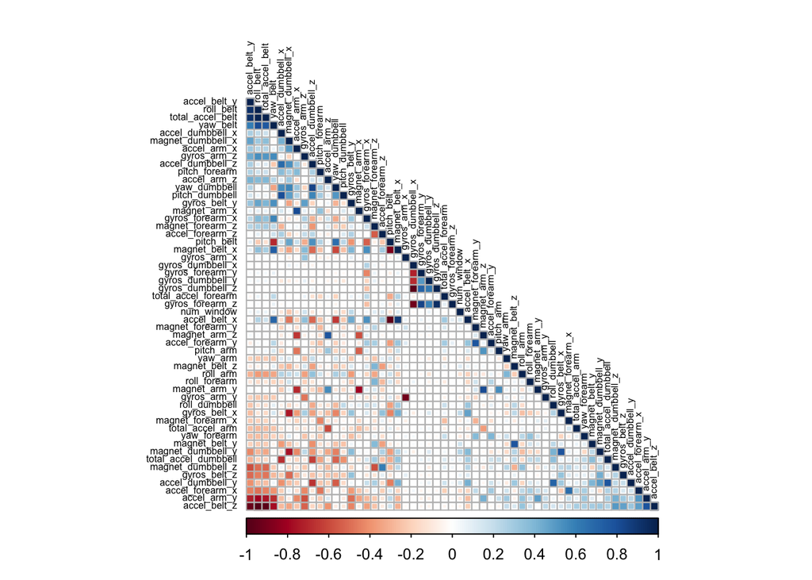

```r
corMatrix <- cor(train.mod.3[, -54])
corrplot(corMatrix, order = "FPC", method = "square",type = "lower",tl.cex = 0.5, tl.col = 'black')
```

## RANDOM FOREST MODEL DEVELOPMENT A Random Forest model is developed through which predictions are to be made.

```r
# Confusion Matrix - Training Data
set.seed(12345)
ctrl.train <- trainControl(method="cv", number=3, verboseIter=FALSE)
modFitRF <- train(classe ~ ., data=train.mod.3, method="rf", trControl=ctrl.train)
modFitRF$finalModel
```

```
##
## Call:
##  randomForest(x = x, y = y, mtry = min(param$mtry, ncol(x)))
##                Type of random forest: classification
##                      Number of trees: 500
## No. of variables tried at each split: 27
##
##         OOB estimate of  error rate: 0.14%
## Confusion matrix:
##      A    B    C    D    E  class.error
## A 5578    1    0    0    1 0.0003584229
## B    6 3789    2    0    0 0.0021069265
## C    0    5 3417    0    0 0.0014611338
## D    0    0    8 3207    1 0.0027985075
## E    0    0    0    3 3604 0.0008317161
```

## DATA PREDICTIONS

Predictions are made for the 20 data cases given in the test data set. The results correspond respectively to the test set data, rows numbered 1-20.

```r
predict.TEST <- predict(modFitRF, newdata=test.mod.3)
predict.TEST
```

```
##  [1] B A B A A E D B A A B C B A E E A B B B
## Levels: A B C D E
```

## CREDITS

1. Ugulino, W.; Cardador, D.; Vega, K.; Velloso, E.; Milidiu, R.; Fuks, H. Wearable Computing: Accelerometers’ Data Classification of Body Postures and Movements. Proceedings of 21st Brazilian Symposium on Artificial Intelligence. Advances in Artificial Intelligence - SBIA 2012. In: Lecture Notes in Computer Science. , pp. 52-61. Curitiba, PR: Springer Berlin / Heidelberg, 2012. ISBN 978-3-642-34458-9. DOI: 10.1007/978-3-642-34459-6_6 (Cited for original base data and approach utilized in this study). https://web.archive.org/web/20161224072740/http:/groupware.les.inf.puc-rio.br/har
2. N. Nishant: Practical Machine Learning - Prediction Assignment Write-up: July 27, 2018 (Referenced for r coding example protocols only).